# Storm Data Analysis in the United States

Brett Jackson

## Synopsis

For this analysis, storm data from the United States were analyzed to determine the storm types which have the largest health and economic effects. The number of fatalties and injuries were considered when evaluating the health impact of storms, and the amount of damage to property and crops was considered when measuring the economic impact. Both the total effect over the full dataset and the median effects were considered.

## Data Processing

The following packages were used in this study:

```r
library(dplyr)
library(tidyr)
library(reshape2)
library(ggplot2)
```

```r
#download.file('https://d396qusza40orc.cloudfront.net/repdata%2Fdata%2FStormData.csv.bz2',
#              destfile = 'StormData.csv.bz2',
#              method = 'curl')
```

The data file containes many variable which are not necessary for this analysis. For the purposes of this analysis, the variables of interest are:

- `BGN_DATE`: Beginning date of the storm
- `EVTYPE`: Storm classification
- `FATALITIES`: Number of fatalities attributed to each storm
- `INJURIES`: Number of injuries attributed to each storm
- `PROPDMG`: Property damage from each storm measured in USD
- `CROPDMG`: Damage to crops from each storm measured in USD

The other variables not used in this study are dropped from the dataset.

Some of these variables are converted into more convenient units, and additional variables are derived from the dataset. These include:

- `DECADE`: Decade when the storm took place
- `PROPDMG`: Recast to billions of USD
- `CROPDMG`: Recast to billions of USD

```r
raw.data <- read.csv(bzfile("StormData.csv.bz2"))
```

```r
# scale factors for converting units
scale.factor <- c('h' = 1e2, 'H' = 1e2,
                  'k' = 1e3, 'K' = 1e3,
                  'm' = 1e6, 'M' = 1e6,
                  'b' = 1e9, 'B' = 1e9)

storm.data <- raw.data %>%
  # select only variables of interest
  select(BGN_DATE, BGN_TIME, EVTYPE, FATALITIES, INJURIES,
         PROPDMG, PROPDMGEXP, CROPDMG, CROPDMGEXP) %>%
  # recast EVTYPE to a factor
  mutate(EVTYPE = as.factor(EVTYPE)) %>%
  # combine BGN_DATE and BGN_TIME and cast as a POSIXct time object
  mutate(BGN_DATE = gsub(' 0:00:00', '', BGN_DATE),
         BGN_DATE_TIME = paste(BGN_DATE, sprintf('%04d', BGN_TIME)),
         BGN_DATE = as.POSIXct(BGN_DATE, format = '%m/%d/%Y')) %>%
  # extract the decade from the date
  mutate(DECADE = 10*floor(as.integer(strftime(BGN_DATE,
                                               format = '%Y'))/10))

# Put property and crop damage into the right units. First, account for the
# exponents (h/k/m/b), and then convert to billions of dollars
storm.data <- storm.data %>%
  mutate(PROPDMGEXP = as.character(PROPDMGEXP),
         CROPDMGEXP = as.character(CROPDMGEXP),
         PROPDMG.SF = ifelse(PROPDMGEXP %in% names(scale.factor),
                             scale.factor[PROPDMGEXP],
                             1.),
         CROPDMG.SF = ifelse(CROPDMGEXP %in% names(scale.factor),
                             scale.factor[CROPDMGEXP],
                             1.),
         PROPDMG = PROPDMG * PROPDMG.SF,
         CROPDMG = CROPDMG * CROPDMG.SF,
         PROPDMG = PROPDMG/1.e9,
         CROPDMG = CROPDMG/1.e9)

# drop columns from the data frame now that we are done with them
storm.data <- storm.data %>%
  select(-BGN_TIME, -BGN_DATE_TIME, -PROPDMGEXP, -CROPDMGEXP, -PROPDMG.SF,
         -CROPDMG.SF)
```

This dataset includes many entries which should be grouped together. For example There are many entries for hurricanes which have different names in the EVTYPE column. There are also several typographic errors.

```r
GroupStormTypes <- function(df, to.match, new.type) {
#   matches <- grepl(to.match, gsub(' ', '', df$EVTYPE), ignore.case = TRUE)
  matches <- grepl(to.match, df$EVTYPE, ignore.case = TRUE)
  df[matches, 'EVTYPE'] = rep(toupper(new.type), times = sum(matches))
  df
}

mod.storm.data <- mutate(storm.data, EVTYPE = as.character(EVTYPE))
mod.storm.data[, 'EVTYPE'] <- toupper(mod.storm.data[, 'EVTYPE'])

replace.list = c('tornado' = 'tornado',
                 'hurricane' = 'hurricane',
                 'tropical storm' = 'tropical storm',
                 'torndao' = 'tornado',
                 'blizzard' = 'blizzard',
                 'coastal[ ]*storm' = 'coastal storm',
                 'tstm' = 'thunderstorm',
                 'th.*[or]+m' = 'thunderstorm',
                 'tunderstorm' = 'thunderstorm',
                 'thundersnow' = 'thundersnow',
                 'avalanch*e' = 'avalanche',
                 'hail' = 'hail',
                 'li[ghtn]*ing' = 'lightning',
                 'flood' = 'flood',
                 'urban.*stream fld' = 'flood',
                 'urban.*sml' = 'urban and small stream',
                 'wnd' = 'wind',
                 'high wind' = 'wind',
                 '^[ ]*wind$' = 'wind',
                 'winds' = 'wind',
                 'wind gusts' = 'wind',
                 'wind damage' = 'wind',
                 'wind storm' = 'wind',
                 '[fv]og' = 'fog',
                 'wint.*mix' = 'wintery mix',
                 'fire' = 'fire',
                 'rain' = 'rain',
                 'micr*oburst' = 'microburst',
                 'excessive rain' = 'excessive rain',
                 'frost' = 'frost',
                 'heavy rain' = 'heavy rain',
                 'heavy shower' = 'heavy rain',
                 'heavy snow' = 'heavy snow',
                 'blowing snow' = 'blowing snow',
                 'heavy swells' = 'high swells',
                 'high  swells' = 'high swells',
                 'heat wave' = 'heat wave',
                 'volcanic' = 'volcanic',
                 'wa[yt]*erspout' = 'waterspout',
                 'heavy snow' = 'heavy snow',
                 '   high surf advisory' = 'high surf advisory',
                 'funnel' = 'funnel cloud',
                 'dust[ ]*storm' = 'dust storm',
                 'dust devil' = 'dust storm',
                 'glaze' = 'glaze',
                 'erosio*n' = 'erosion',
                 'landslide' = 'landslide',
                 'winter storm' = 'winter storm',
                 'mudslide' = 'mudslide',
                 'hyp[oer]*thermia' = 'hypothermia',
                 'blow-out tide' = 'blow-out tide',
                 'extreme cold' = 'extreme cold',
                 'record  cold' = 'record cold',
                 'dam break' = 'dam failure',
                 'bitter wind chill' = 'wind chill',
                 'extreme wind[ ]*chill' = 'wind chill',
                 'flash floooding' = 'flood',
                 'drought' = 'drought',
                 'ice.*road' = 'ice',
                 'ice.*snow' = 'ice and snow',
                 'early snowfall' = 'early snow',
                 'falling snow/ice' = 'snow',
                 'gradient wind' = 'wind',
                 'gusty.*wind' = 'wind',
                 'heavy precipatation' = 'heavy precipitation',
                 'high surf' = 'high surf',
                 'lake-effect snow' = 'lake effect snow',
                 'snow.*ice' = 'snow',
                 'snow.*cold' = 'snow',
                 'snow and' = 'snow',
                 'snow shower' = 'snow',
                 'snow squall' = 'snow squall',
                 'marine mishap' = 'marine accident',
                 'hazardous surf' = 'heavy surf and wind',
                 'and$' = '?',
                 '^none$' = '?',
                 'apache county' = '?',
                 '^other?' = '?',
                 '^excessive$' = '?',
                 '^southeast$' = '?',
                 '^high$' = '?',
                 'summary' =  'summary')

for (key in names(replace.list)) {
  mod.storm.data <- GroupStormTypes(mod.storm.data,
                                    key,
                                    replace.list[[key]])
}

mod.storm.data <- mutate(mod.storm.data, EVTYPE = as.factor(EVTYPE))
```

This data frame is then transformed to allow for easier analysis. The data frame is “melted” into a long format where each storm type has four entries. One each for fatalities, injuries, property damage, and crop damage.

```r
all.effects <- mod.storm.data %>%
  select(EVTYPE, FATALITIES, INJURIES, PROPDMG, CROPDMG) %>%
  melt(id = 'EVTYPE')
```

There are multiple ways of evaluating the effect of a storm. These include looking at the total healh effects and damage, or the median.

```r
# Function to apply a cut on the data frame. This function takes as input a
# data frame and an integer, head.size. head.size represents the number of
# rows selected from the sorted list from each effect category.
ApplyCuts <- function(df, head.size = 5) {
  # Function which assigns a rank to each entry in a given column
  AssignRank <- function(unsorted.df, column.to.rank) {
    # sort the data frame based on the column of choice
    sorted.df <- unsorted.df[order(unsorted.df[,column.to.rank],
                                   decreasing = TRUE), ]

    # assign a rank based on the sorted data frame (calling order on a sorted
    # list will just give the position)
    sorted.df[, paste('rank',
                      column.to.rank,
                      sep = '.')] = order(sorted.df[,column.to.rank],
                                          decreasing = TRUE)
    # return the sorted data frame
    sorted.df
  }

  for (category in c('FATALITIES', 'INJURIES', 'PROPDMG', 'CROPDMG')) {
    df <- AssignRank(df, category)
  }

  # filter based on the rank, and drop the rank columns. Then return the
  # filtered data frame
  filter(df,
         rank.FATALITIES <=head.size |
         rank.INJURIES <= head.size |
         rank.PROPDMG <= head.size |
         rank.CROPDMG <= head.size) %>%
    select(-rank.FATALITIES, -rank.INJURIES, -rank.PROPDMG, -rank.CROPDMG)
}
```

### Total effect

There are many storm types in this dataset, however, only the most damaging are of interest for this study. The data can be trimmed to focus on these storms of interest. Only the top 5 storm types were selected for each health or economic effect.

```r
total.effects <- all.effects %>%
  # find total effect for each sorm type
  dcast(EVTYPE ~ variable, sum) %>%
  ApplyCuts(head.size = 5)
```

### Median effect

As with analyzing the total effect, when assessing the median effect, only the most damaging storm classifications are of interest. Again, only the 5 storm types with the highest median in each category were selected for this analysis.

```r
median.effects <- all.effects %>%
  # find median effect for each sorm type
  dcast(EVTYPE ~ variable, median) %>%
  ApplyCuts(head.size = 5)
```

## Results

A helper function is defined to make plotting consistent.

```r
DrawEffectPlots <- function(df,
                            xlab = 'Storm type',
                            ylab = 'Effect',
                            title = 'Effect') {
  mf_labeller <- function(var, value){
    value <- as.character(value)
    if (var=="variable") {
      value[value=="FATALITIES"] <- "Fatalities"
      value[value=="INJURIES"]   <- "Injuries"
      value[value=="PROPDMG"] <- "Property damage"
      value[value=="CROPDMG"]   <- "Crop damage"
      }
    return(value)
    }

  g <- df %>%
    melt(id = c('EVTYPE')) %>%
    filter(value > 0) %>%
    ggplot(aes(EVTYPE, y = value))

  g + geom_point(size = 3) +
    facet_grid(variable~., scales = 'free', labeller = mf_labeller) +
    theme(text = element_text(size = 16),
          axis.text.x = element_text(angle = 65, hjust = 1)) +
  labs(x = xlab,
       y = ylab,
       title = title) +
  scale_y_log10()
}
```

An additional helper fucntion is created to extract the storm type with the largest effect of a given type.

```r
ExtractLargestEffect <- function(df, column.to.rank) {
  the.order <- order(df[, column.to.rank], decreasing = TRUE)
  df[the.order[[1]],]
}
```

### Total effect

In order to determine the storm type that has had the largest total health and economic effect, one can make a plot of the total effect in the categories of interest. Namely, number of fatalities, number of injuries, property damage, and crop damage (both measured in billions of US dollars).

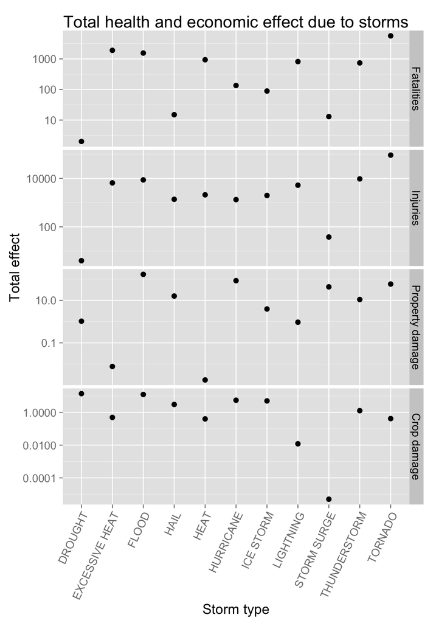

```r
DrawEffectPlots(total.effects,
                ylab = 'Total effect',
                title = 'Total health and economic effect due to storms')
```

```r
largest.total.fatalities <- ExtractLargestEffect(total.effects, 'FATALITIES')
largest.total.injuries <- ExtractLargestEffect(total.effects, 'INJURIES')
largest.total.propdmg <- ExtractLargestEffect(total.effects, 'PROPDMG')
largest.total.cropdmg <- ExtractLargestEffect(total.effects, 'CROPDMG')
```

### Median effect

The total effect is of course important, however the median effect can be used to estimate the effect of a typical storm of each category.

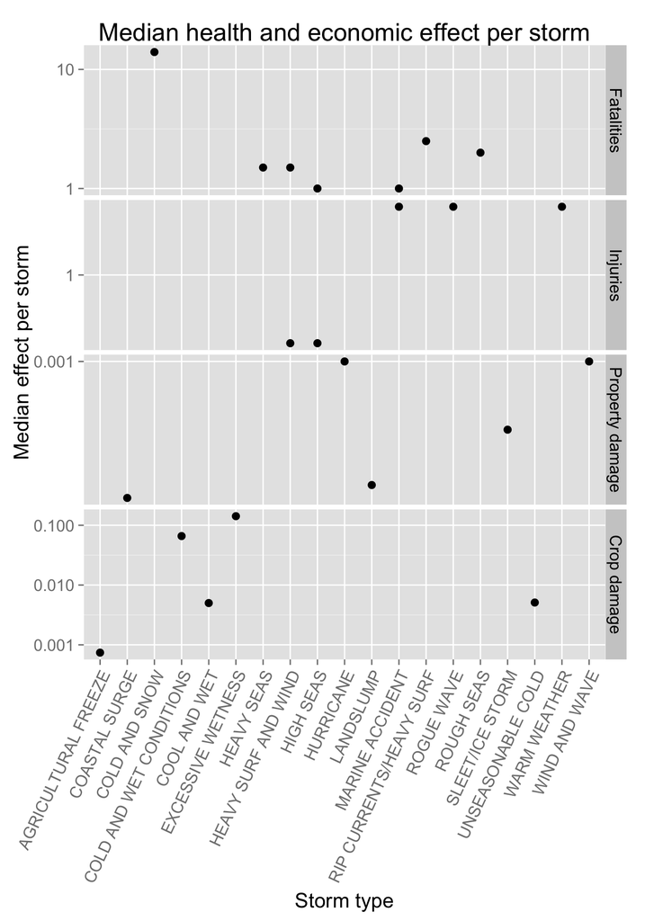

```r
DrawEffectPlots(median.effects,
                ylab = 'Median effect per storm',
                title = 'Median health and economic effect per storm')
```

```r
largest.median.fatalities <- ExtractLargestEffect(median.effects, 'FATALITIES')
largest.median.injuries <- ExtractLargestEffect(median.effects, 'INJURIES')
largest.median.propdmg <- ExtractLargestEffect(median.effects, 'PROPDMG')
largest.median.cropdmg <- ExtractLargestEffect(median.effects, 'CROPDMG')
```